# PolNet Intro Network Analysis 2022

Alex Genovese

2022-06-13

# Session 1

## Terms

- Network: A collection of **nodes** joined by **edges**
- Node: Unit we are examining
  - Could be countries, people, cities, etc.
  - Synonyms: vertex, actors
- Edge: Connection between two nodes
- One-mode networks: all actors are tied to one another according to one relation (e.g. friendship)
- Two-mode networks: Actors are tied to particular events
- Types of Networks:
  - Undirected, binary
  - Directed, binary
  - Undirected, Valued
  - Directed, Valued
- Data: Adjenecy matrix vs. edge list
  - Adjency matrix - values show connection between nodes (often omit 0, just care about 1 if binary)
  - Edge list - 2 columns, node 1/node 2 (Sometimes 3rd column for weight if not binary; usually missing edges not included)

# Session 2

## Network Density

- Density refers to the proportion of ties in a network that are actually present
  - In undirected networks: $d =\frac{L}{n(n-1)/2}$ where L refers to the actual number of lines present in the network and n to the number of nodes present in the network
  - In directed networks: $d = \frac{L}{n(n-1)}$

## Subgraphs

- Dyad
  - Is the relationship reciprocal?
  - Mutual, asymmetric, or null?
- Triad
  - Transitivity
  - A to B, B to C, and A to C
  - “States are more likely to send diplomatic missions to countries where their diplomatic partners also send missions” (Kinne 2014)

## Research Design

- Network as IV
  - Friendship -> Behavior
  - Centrality -> Promotion
- Network as DV
  - Homophily -> Friendship
  - Personality -> Central actors

## Centrality

- Why do we care about central nodes?
  - Relational ties (linkages) between actors are channels for transfer or “flow” of resources.
  - Network models focusing on individuals view the network structural environment as providing opportunities for or constraints on individual action (Wasserman and Faust 1994)
- In terms of information flows?
  - Get the information earlier than others
  - Control the flow of information
- What does it mean for an actor to be central?
  - Prominent, influential
  - Having great visibility, prestige, power, control, autonomy
  - Leaders, gatekeepers
  - “For non-negative relations such as friendship or trust, centrality tends to be viewed as a positive thing for nodes, providing actors with opportunities to influence others and receive flows (i.e., information).”
- Degree centrality
  - Total number of ties: $d_{i} = \Sigma_{j}x_{ij}$
- Eigenvector centrality
  - Proportional to the sum of centralities of the nodes it is connected to
  - If one’s alters have high degree centrality, then the focal actor has high eigenvector centrality
  - $e_{i} = \lambda\Sigma_{j}x_{ij}e_{j}$
  - Ego: focal actor
  - Alters: the nodes that ego is connected
- Betweenness Centrality
  - How often an actor rests between two other actors
  - $C_{B}(k) = \Sigma\frac{\alpha_{ikj}}{\alpha_{ij}}, i\neq j \neq k,$ where $\alpha_{ikj}$ is the number of geodesics linking actors i and j that pass through node k and $\alpha_{ij}$ is the number of geodesics linking actors k and j (geodesic means the shortest path in the network)
- Closeness Centrality
  - Emphasizes an actor’s independence
  - If an actor is not central, the actor generally needs to rely on others to relay messages through the network. Thus, an actor who is close to many other actors is a very independent actor.

## Network statistics and centrality R

# Session 3

## Networks including negative ties

### Examples:

- The friend of my friend is my friend
- The friend of my enemy is my enemy
- The enemy of my friend is my enemy
- The enemy of my enemy is my friend
- Cognitive units or entities tend to attain balance, “a situation in which the perceived units and the experienced sentiments co-exist without stress”
  - Is this a common pattern in individuals?
  - How about countries?

## Negative Centrality

- Focus on A
- “The recipient of a negative tie would be less affected by receiving a negative tie from an actor who gave out a lot of negative ties than if they were the sole recipient of a negative tie from an actor that only gave one negative tie.”
- $PN = (I - \frac{1}{2n-2}A)^{-1}1$
  - A=P-2N, P denotes a positive tie matrix and N denotes a negative tie matrix.
  - If both positive and negative ties are possible, then it ranges from -1 to 2.

```r
library(signnet)
```

```r
pndata <- import("pndata.xlsx")
pnnet <- graph_from_data_frame(pndata, directed=F)

pnnet
```

```
## IGRAPH 5abd2ef UN-- 8 8 --
## + attr: name (v/c), sign (e/n)
## + edges from 5abd2ef (vertex names):
## [1] A--B A--C A--D B--C B--D B--F X--Y Y--Z
```

```r
E(pnnet)$sign
```

```
## [1]  1 -1  1 -1  1 -1  1 -1
```

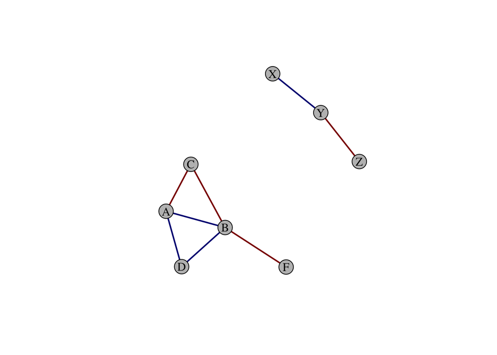

```r
plot(pnnet,
     vertex.label.color="black",
     vertex.frame.color="black",
     vertex.color="gray",
     edge.width=2,
     edge.color=ifelse(E(pnnet)$sign==-1, "darkred", "navy"))
```

```r
### Number of triangles
count_signed_triangles(pnnet)
```

```
## +++ ++- +-- ---
##   1   0   1   0
```

```r
### Balanced?
balance_score(pnnet, method = "triangles") ##Aref&Wilson (2018):0 to 1
```

```
## [1] 1
```

```r
## Degree centrality
degree_signed(pnnet, type = "pos")
```

```
## A B X Y C D F Z
## 2 2 1 1 0 2 0 0
```

```r
degree_signed(pnnet, type = "neg")
```

```
## A B X Y C D F Z
## 1 2 0 1 2 0 1 1
```

```r
degree_signed(pnnet, type = "ratio")
```

```
##         A         B         X         Y         C         D         F         Z
## 0.6666667 0.5000000 1.0000000 0.5000000 0.0000000 1.0000000 0.0000000 0.0000000
```

```r
degree_signed(pnnet, type = "net")
```

```
##  A  B  X  Y  C  D  F  Z
##  1  0  1  0 -2  2 -1 -1
```

```r
## Positive and negative centrality
pn_index(pnnet) # range: -1 to 2
```

```
##         A         B         X         Y         C         D         F         Z
## 1.0453671 0.9297432 1.0680628 0.9528796 0.7178414 1.1410793 0.8671795 0.8638743
```

```r
## All positive ties
pnnet2 <- graph_from_data_frame(pndata, directed=F)
E(pnnet2)$sign <- 1
pn_index(pnnet2) # range: 1 to 2
```

```
##        A        B        X        Y        C        D        F        Z
## 1.264992 1.338030 1.082474 1.154639 1.185930 1.185930 1.095574 1.082474
```

```r
## All negative ties
pnnet3 <- graph_from_data_frame(pndata, directed=F)
E(pnnet3)$sign <- -1
pn_index(pnnet3) # range: 0 to 1
```

```
##         A         B         X         Y         C         D         F         Z
## 0.6878802 0.5339261 0.8936170 0.7446809 0.8254562 0.8254562 0.9237248 0.8936170
```

```r
## Real data: rivalry and alliance in the Middle East

pnnet_me <- import("rivdefme1980.csv")
head(pnnet_me)
```

```
##   stateabb1 stateabb2 year sign
## 1       USA       RUS 1980   -1
## 2       USA       IRN 1980   -1
## 3       USA       TUR 1980    1
## 4       USA       IRQ 1980   -1
## 5       USA       SYR 1980   -1
## 6       RUS       IRN 1980   -1
```

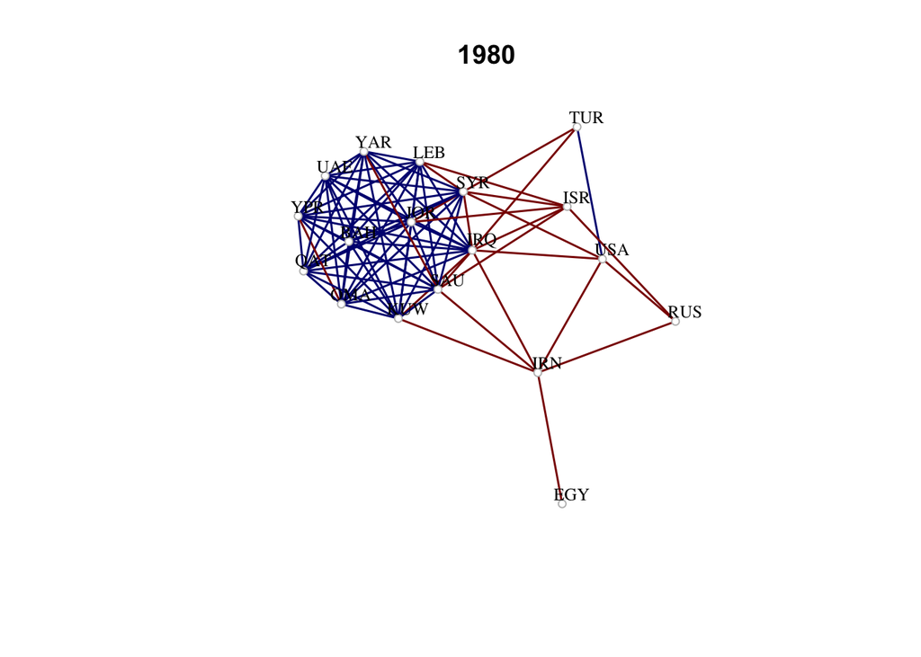

```r
pnnet_1980 <-graph_from_data_frame(d=pnnet_me, directed=F)
E(pnnet_1980)$color <- ifelse(E(pnnet_1980)$sign==-1, "darkred", "navy")

plot(pnnet_1980,
     edge.color=E(pnnet_1980)$color,
     edge.width=1.5,
     vertex.size=4,
     vertex.frame.color="gray",
     vertex.color="white",
     vertex.label.cex=0.8,
     vertex.label.color="black",
     vertex.label.dist=1,
     layout=layout_with_kk,
     main="1980")
```

```r
### Number of triangles
count_signed_triangles(pnnet_1980)
```

```
## +++ ++- +-- ---
## 157  56  16  10
```

```r
### Balanced?
balance_score(pnnet_1980, method = "triangles") ##Aref&Wilson (2018):0 to 1
```

```
## [1] 0.7238494
```

```r
## Degree centrality
degree_signed(pnnet_1980, type = "pos")
```

```
## USA RUS IRN TUR IRQ SYR LEB JOR ISR SAU YAR YPR KUW BAH QAT UAE EGY OMA
##   1   0   0   1   8   8  10  10   0   9  10  10  10  11  11  11   0  10
```

```r
degree_signed(pnnet_1980, type = "neg")
```

```
## USA RUS IRN TUR IRQ SYR LEB JOR ISR SAU YAR YPR KUW BAH QAT UAE EGY OMA
##   4   3   6   2   7   6   2   2   6   4   1   1   2   0   0   0   1   1
```

```r
degree_signed(pnnet_1980, type = "ratio")
```

```
##       USA       RUS       IRN       TUR       IRQ       SYR       LEB       JOR
## 0.2000000 0.0000000 0.0000000 0.3333333 0.5333333 0.5714286 0.8333333 0.8333333
##       ISR       SAU       YAR       YPR       KUW       BAH       QAT       UAE
## 0.0000000 0.6923077 0.9090909 0.9090909 0.8333333 1.0000000 1.0000000 1.0000000
##       EGY       OMA
## 0.0000000 0.9090909
```

```r
degree_signed(pnnet_1980, type = "net")
```

```
## USA RUS IRN TUR IRQ SYR LEB JOR ISR SAU YAR YPR KUW BAH QAT UAE EGY OMA
##  -3  -3  -6  -1   1   2   8   8  -6   5   9   9   8  11  11  11  -1   9
```

```r
## Positive and negative centrality
pn_index(pnnet_1980) # range: -1 to 2
```

```
##       USA       RUS       IRN       TUR       IRQ       SYR       LEB       JOR
## 0.8253980 0.8770239 0.6460253 0.9124294 0.9373274 0.9640714 1.2806180 1.2806180
##       ISR       SAU       YAR       YPR       KUW       BAH       QAT       UAE
## 0.6191703 1.1344464 1.3013956 1.2882154 1.2813758 1.3986339 1.3986339 1.3986339
##       EGY       OMA
## 0.9619985 1.2882154
```